# Lab 1

Magnus Wood

9-16-21

```r
library(tidyverse)
library(grid)
library(gridExtra)
library(ggpubr)
library(patchwork)
```

```r
cal_data <- read_csv("Lab 1_ InsMea/CR1000_1.dat", skip=4)
col_names <- c("TIMESTAMP", "RECORD", "kohms_Avg", "LWmV_Avg", "PTemp_C_Avg")
names(cal_data) <- col_names


cal_data <- cal_data %>%
  filter(RECORD < 118) %>%
  select(kohms_Avg, LWmV_Avg)

n = length(cal_data$LWmV_Avg)

cal_sum <- cal_data %>%
  summarize(mean = mean(LWmV_Avg),
            sd = sd(LWmV_Avg))


cal_err <- qt(0.95, df=n-1) * cal_sum$sd / sqrt(n)
left <- cal_sum$mean - cal_err
right <- cal_sum$mean + cal_err

print(paste(n, left, right))

print(paste("boolean wetness threshold (95 CI) is: ", right))
```

[output not shown]

```r
my_data <- read_csv("Lab 1_ InsMea/CR1000_1_corrected.csv")
# col_names <- c("TIMESTAMP", "RECORD", "kohms_Avg", "LWmV_Avg", "PTemp_C_Avg")
# names(my_data) <- col_names

# kilohms   mV  Deg C

# 1. Room Temp: 21 C
# Trial 1 14:52:00 - 14:57:00
# Trial 2 14:59:00 - 15:04:00
# Trial 3 15:06:00 - 15:11:00
#
# 2. Warm: 32 C
# Trial 1 16:17:00 - 16:22:00
# Trial 2 16:29:00 - 16:34:00
# Trial 3 16:44:00 - 16:49:00
#
# 3. Cold (11 C)
# Trial 1 16:51:00 - 16:56:00
# Trial 2 16:57:05 - 17:02:05
# Trial 3 17:05:00 - 17:10:00
#
#
#
# # trial 1, 14:52:00 - 14:57:0, 205:265
# trial_1 <- my_data %>% filter(RECORD >= 205, RECORD <= 265) %>% mutate(trial = 1)
#
# # Trial 2 (14:59:00 - 15:04:00) 289:349
# trial_2 <- my_data %>% filter(RECORD >= 289, RECORD <= 349) %>% mutate(trial = 2)
#
# # Trial 3 (15:06:00 - 15:11:00), 373:433
# trial_3 <- my_data %>% filter(RECORD >= 373, RECORD <= 433) %>% mutate(trial = 3)
#
# # combined
# trial_data <- my_data %>% mutate(trial = ifelse(RECORD >= 205 & RECORD <= 265, 1, ifelse(RECORD >= 289 & RECORD <= 349, 2, ifelse(RECORD >= 373 & RECORD <= 433, 3, 0)))) %>% filter(trial > 0) %>%
#   mutate(timepoint = ifelse(RECORD >= 205 & RECORD <= 265, RECORD - 205, ifelse(RECORD >= 289 & RECORD <= 349, RECORD - 289, ifelse(RECORD >= 373 & RECORD <= 433, RECORD - 373, 0))))
# #
# # DF$Den <- ifelse(DF$Denial1 < 1 & !is.na(DF$Denial1) | DF$Denial2 < 1 &
# # !is.na(DF$Denial2) | DF$Denial3 < 1 & !is.na(DF$Denial3), "0", "1")
# #
# # Then to ensure a value of NA if all values of the conditional variables are NA:
#
#
```

```r
excluded_vars <- c("X9", "date", "record", "room_temp")

trial_data_long <- my_data %>%
  select(-excluded_vars) %>%
  #Vs=(2.5 V)/(Rs+101)
  mutate(mv_237 = 1000 * (2.5/(kohms + 101))) #converting the resistor value of Rs to voltage

pruned_trial_data <- trial_data_long

plot_1 <- trial_data_long %>%
  ggplot(aes(x=time_s, y=kohms, color=factor(trial))) +
  geom_line() +
  facet_wrap(~water_temp) +
  ylab("kiloohms") +
  xlab("time (s)") +
  labs(color = "trial")

plot_1
ggsave("c:/data/bsyse_541/lab1/237_kohms_behavior.png", width=6, height=3, dpi=1000)

plot_2 <- trial_data_long %>%
  ggplot(aes(x=time_s, y=mv, color=factor(trial))) +
  geom_line() +
  facet_wrap(~water_temp) +
  ylab("millivolts") +
  xlab("time (s)") +
  labs(color = "trial")

plot_2
ggsave("c:/data/bsyse_541/lab1/lws_mV_behavior.png", width=6, height=3, dpi=1000)

# combine into a figure
figure <- ggarrange(plot_2, plot_1, common.legend = TRUE,
                    labels = c("LWS", "237"))

annotate_figure(figure,top = text_grob("Leaf Wetness Sensor signal over time",
                   color = "black", face = "bold", size = 12))

ggsave("c:/data/bsyse_541/lab1/all_trials_all_sensors_outliers.png", dpi=1000)
```

[output not shown]

Step 4. Experiment

1. Mount the two wetness sensors at an angle of 45° to ground level in a tree or lab conditions.
2. Use may or may not use an electric fan to generate crosswind at low speed. The fan will locate at a distance of 1 m to sensors and adjust the height to make sure the crosswind blowing directly on the wetness sensors.
3. Upload the program to the data logger and read the real-time data to check if the setup of data logger, and connection of sensors are working properly.
4. Spray the wetness sensors with a water bottle sprayer (equal amounts between replications), while the fan is on. Wipe your wetness sensors gently (do not rub, soak dry with paper towel).
5. The variable that you will change will be water temperature (use three different temperatures, at room temperature, warm, and cold. Measure the water temperature with the thermometer.
6. Replicate the experiment at least three times at temperature setting. Make sure that you measure the water temperature.

Results and discussion should answer the following questions:

```r
# 1. Does the water temperature affect the sensor sensitivity (each sensor)?

# LWS leaf wetness sensor
# wet dry transition is normally between 50 and 200 kOhms
# The resistance of the sensor at the wet/dry transition point should be
# determined. A sharp change in resistance occurs in the wet-dry transition on
# the uncoated sensor; normally the transition is between 50 and 200 kΩ. Coated
# sensors have a poorly defined transition which normally occurs from 20 kΩ to
# above 1,000 kΩ. For best results, the leaf wetness sensor should be field
# calibrated since the transition point will vary for different areas and vegetation.

################################ CI 237 sensor (kohms) ##############################################################

# filter/select data
pruned_237_kohms <- trial_data_long %>%
  select(trial, water_temp, time_s, kohms) %>%
  filter(!(trial == 2 & water_temp == 11)) %>% # excluding 237/11C/Trial2
  pivot_longer(cols= c('kohms'), names_to="units", values_to="values") %>%
  mutate(water_temp = as.factor(water_temp))

# calculate mean and sd
sample_sum <- pruned_237_kohms %>%
  group_by(time_s, water_temp) %>%
  summarize(mean = mean(values),
            sd   = sd(values),
            mean_p2sd = mean +  sd,
            mean_m2sd = mean - sd) %>%
  ungroup()
mean_237 <- sample_sum

# plot
p_237_kohms <- ggplot(sample_sum, aes(x = time_s,  color = fct_rev(water_temp))) +
  geom_ribbon(aes(ymin = mean_m2sd, ymax = mean_p2sd), alpha = 0.1) +
  geom_point(aes(y=mean)) +
  labs(color = "Water Temp (C)") +
  ylab("kOhms") + xlab("time (seconds)")

# save plot
ggsave("c:/data/bsyse_541/lab1/237_value_time.png", width=6, height=3, dpi=1000)

################################ CI 237 sensor (mV conversion) ######################################################
#Vs=(2.5 V)/(Rs+101).
#converting the resistor value of Rs to voltage
pruned_sensorspec_data <- trial_data_long %>%
  select(trial, water_temp, time_s, kohms) %>% # select only the columns of interest
  filter(!(trial == 2 & water_temp == 11)) %>% # excluding 237/11C/Trial2
  mutate(mV = 1000 * (2.5/(kohms + 101))) %>% # convert resistance back to sensor voltage
  pivot_longer(cols= c('mV'), names_to="units", values_to="values") %>%
  mutate(water_temp = as.factor(water_temp))

# calculate sample means and sd
sample_sum <- pruned_sensorspec_data %>%
  group_by(time_s, water_temp) %>%
  summarize(mean = mean(values),
            sd   = sd(values),
            mean_p2sd = mean +  sd,
            mean_m2sd = mean - sd) %>%
  ungroup()

# plot
p_237_mV <- ggplot(sample_sum, aes(x = time_s,  color = fct_rev(water_temp))) +
  geom_ribbon(aes(ymin = mean_m2sd, ymax = mean_p2sd), alpha = 0.1) +
  geom_point(aes(y=mean)) +
  labs(color = "Water Temp (C)") +
  ylab("mV") + xlab("time (seconds)")

# save plot
ggsave("c:/data/bsyse_541/lab1/237_mVconversionvalue_time.png", width=6, height=3, dpi=1000)

################################### CI LWS sensor (mV)    ################################################
# LWS sensor is in mV
pruned_sensorspec_data <- trial_data_long %>%
  select(trial, water_temp, time_s, mv) %>% # select only the columns of interest
  filter(!(trial == 3 & water_temp == 21)) %>% # excluding LWS trial 3 in temp 21
  pivot_longer(cols= c('mv'), names_to="units", values_to="values") %>%
  mutate(water_temp = as.factor(water_temp))

# sample means and sd
sample_sum <- pruned_sensorspec_data %>%
  group_by(time_s, water_temp) %>%
  summarize(mean = mean(values),
            sd   = sd(values),
            mean_p2sd = mean + sd,
            mean_m2sd = mean - sd) %>%
  ungroup()

mean_lws <- sample_sum
# plot

p_lws_mv <- ggplot(sample_sum, aes(x = time_s,  color = fct_rev(water_temp))) +
  geom_ribbon(aes(ymin = mean_m2sd, ymax = mean_p2sd), alpha = 0.1) +
  geom_point(aes(y=mean)) +
  labs(color = "Water Temp (C)") +
  ylab("milliVolts") + xlab("time (seconds)")

# save plot
ggsave("c:/data/bsyse_541/lab1/lws_value_time.png", width=6, height=3, dpi=1000)

################################################### combine into one figure ###################################################
figure <- ggarrange(p_lws_mv, p_237_kohms, common.legend = TRUE,
                    labels = c("LWS", "237"))
```

```r
annotate_figure(figure,top = text_grob("Leaf Wetness Sensor values over time",
                   color = "black", face = "bold", size = 12))
ggsave("c:/data/bsyse_541/lab1/combined_mv_value_time.png", width=6, height=3, dpi=1000)
```

[output not shown]

```r
# var for text size
textsize = 6

############################################# LWS SENSOR TUKEY ANOVA ##################################################
# LWS sensor is in mV
pruned_lws_mv <- trial_data_long %>%
  select(trial, water_temp, time_s, mv) %>% # select only the columns of interest
  filter(!(trial == 3 & water_temp == 21)) %>% # excluding LWS trial 3 in temp 21
  pivot_longer(cols= c('mv'), names_to="units", values_to="values") %>%
  mutate(water_temp = as.factor(water_temp))


pruned_sensorspec_data <- pruned_lws_mv

# perform anova and tukeys now
anova <- aov(values ~ water_temp, data = pruned_sensorspec_data)
summary(anova)
```

```
             Df Sum Sq Mean Sq F value Pr(>F)
water_temp    2  91421   45710   66.22 <2e-16 ***
Residuals   485 334785     690
---
Signif. codes:  0 ‘***’ 0.001 ‘**’ 0.01 ‘*’ 0.05 ‘.’ 0.1 ‘ ’ 1
```

```r
# Tukey's test
tukey <- TukeyHSD(anova)
print(tukey)
```

```
  Tukey multiple comparisons of means
    95% family-wise confidence level

Fit: aov(formula = values ~ water_temp, data = pruned_sensorspec_data)

$water_temp
           diff       lwr       upr p adj
21-11 -16.70109 -23.92042  -9.48177 3e-07
32-11 -31.59617 -38.05333 -25.13902 0e+00
32-21 -14.89508 -22.11440  -7.67576 5e-06
```

```r
# # compact letter display
cld <- multcompView::multcompLetters4(anova, tukey)
cld <- as.data.frame.list(cld$water_temp)

# Boxplot with Letters Indicating Significant Differences, https://www.youtube.com/watch?v=Pc1RVwEIT5k
# # # table with factors and 3rd quantile
Tk <- pruned_sensorspec_data %>% group_by(water_temp) %>%
  summarise(mean=mean(values), quant = quantile(values, probs = 0.75)) %>%
  arrange(desc(mean))

# extract the compact letter display and add to the Tk table
Tk$cld <- cld$Letters

# boxplot
Tk_plot1 <- ggplot(pruned_sensorspec_data, aes(water_temp, values, fill = fct_rev(water_temp))) + geom_boxplot() +
  labs(x = "water temperature (C)", fill = "Water Temp (C)") +
  ylab("signal (mV)") +
  theme_bw() +
  theme(panel.grid.major = element_blank(), panel.grid.minor = element_blank()) +
  geom_text(data = Tk, aes(x = water_temp, y = quant, label=cld), vjust = -1, hjust = -1, size = textsize) +
  # scale_fill_brewer(palette = "Blues") +
  geom_point(aes(water_temp, values), color="darkred")

Tk_plot1

ggsave("c:/data/bsyse_541/lab1/lws_tukey_boxplot.png", width=6, height=3, dpi=1000)
```

[output not shown]

```r
############################## CI 237 TUKEY ANOVA TESTS ###############################################
pruned_237_kohms <- trial_data_long %>%
  select(trial, water_temp, time_s, kohms) %>%
  filter(!(trial == 2 & water_temp == 11)) %>% # excluding 237/11C/Trial2
  pivot_longer(cols= c('kohms'), names_to="units", values_to="values") %>%
  mutate(water_temp = as.factor(water_temp))

pruned_sensorspec_data <- pruned_237_kohms
# perform anova and tukeys now
anova <- aov(values ~ water_temp, data = pruned_sensorspec_data)
summary(anova)
```

```
             Df Sum Sq Mean Sq F value Pr(>F)
water_temp    2  639.9   320.0    5729 <2e-16 ***
Residuals   485   27.1     0.1
---
Signif. codes:  0 ‘***’ 0.001 ‘**’ 0.01 ‘*’ 0.05 ‘.’ 0.1 ‘ ’ 1
```

```r
# Tukey's test
tukey <- TukeyHSD(anova)
print(tukey)
```

```
  Tukey multiple comparisons of means
    95% family-wise confidence level

Fit: aov(formula = values ~ water_temp, data = pruned_sensorspec_data)

$water_temp
            diff        lwr        upr p adj
21-11 -2.0879536 -2.1528933 -2.0230138     0
32-11  0.4220519  0.3571122  0.4869916     0
32-21  2.5100055  2.4519216  2.5680893     0
```

```r
# compact letter display
cld <- multcompView::multcompLetters4(anova, tukey)
cld <- as.data.frame.list(cld$water_temp)

# Boxplot with Letters Indicating Significant Differences, https://www.youtube.com/watch?v=Pc1RVwEIT5k
# table with factors and 3rd quantile
Tk <- pruned_sensorspec_data %>% group_by(water_temp) %>%
  summarise(mean=mean(values), quant = quantile(values, probs = 0.75)) %>%
  arrange(desc(mean))

# extract the compact letter display and add to the Tk table
Tk$cld <- cld$Letters

# boxplot
Tk_plot3 <- ggplot(pruned_sensorspec_data, aes(water_temp, values, fill = fct_rev(water_temp))) + geom_boxplot() +
  labs(x = "water temperature (C)", y="signal (kiloohms)", fill = "Water Temp (C)") +
  theme_bw() +
  theme(panel.grid.major = element_blank(), panel.grid.minor = element_blank()) +
  geom_text(data = Tk, aes(x = water_temp, y = quant, label=cld), vjust = 1.5, hjust = -1, size = textsize) +
  # scale_fill_brewer(palette = "Blues") +
  geom_point(aes(water_temp, values), color="darkred")

# save plot
ggsave("c:/data/bsyse_541/lab1/237_tukey_boxplot.png", width=6, height=3, dpi=1000)
```

```r
############################################### combined figure for report ############################################
figure <- ggarrange(Tk_plot1, Tk_plot3, common.legend = TRUE,
                    labels = c("LWS", "237"))

annotate_figure(figure,top = text_grob("Mean signal values for each water temperature and sensor",
                   color = "black", face = "bold", size = 12))
ggsave("c:/data/bsyse_541/lab1/combined_tukey_boxplot_values.png", dpi=1000)
```

[output not shown]

# 2. Which sensor was more sensitive?

A sensor’s sensitivity is defined as a change in output over a change in input. Output is in mV or kiloohms, depending on sensor, input is in time?

```r
# change in output over time should give an idea of sensistivity as the sensors are drying over time
sens_237 <- pruned_237_kohms %>%
  filter(time_s == 0 | time_s == 300) %>%
  group_by(water_temp, time_s) %>%
  summarize(mean = mean(values))
s_237 <- c()
s_lws <- c()
water_temp <- c(11, 21, 32)

s_237[1] <- ((sens_237$mean[2] - sens_237$mean[1]) / 300) * 60 #change in output over time, in kiloohm / minute
s_237[2] <- ((sens_237$mean[4] - sens_237$mean[3]) / 300) * 60
s_237[3]  <-((sens_237$mean[6] - sens_237$mean[5]) / 300) * 60

sens_lws <- pruned_lws_mv %>%
  filter(time_s == 0 | time_s == 300) %>%
  group_by(water_temp, time_s) %>%
  summarize(mean = mean(values))
s_lws[1] <- ((sens_lws$mean[2] - sens_lws$mean[1]) / 300) * 60 #change in output over time, in mV / minute
s_lws[2] <- ((sens_lws$mean[4] - sens_lws$mean[3]) / 300) * 60 #change in output over time, in mV / minute
s_lws[3]  <- ((sens_lws$mean[6] - sens_lws$mean[5]) / 300) * 60 #change in output over time, in mV / minute

sens_df <- tibble(water_temp, s_lws, s_237) %>%
  pivot_longer(cols = c('s_lws', 's_237'), names_to = 'sensor', values_to = 'sensitivity') %>%
  mutate(water_temp = as.factor(water_temp))

#plot
sens_plot_lws <- sens_df %>%
  filter(sensor == 's_lws') %>%
  ggplot(aes(x=sensor, y=sensitivity, color=fct_rev(water_temp))) +
  labs(color = "water temperature", y="sensitivity (mV/minute)") +
  geom_point()

sens_plot_237 <- sens_df %>%
  filter(sensor == 's_237') %>%
  ggplot(aes(x=sensor, y=sensitivity, color=fct_rev(water_temp))) +
  labs(color = "water temperature", y="sensitivity (kiloohm/minute)") +
  geom_point()


############################################### combined figure for report ############################################
figure <- ggarrange(sens_plot_lws, sens_plot_237, common.legend = TRUE,
                    labels = c("LWS", "237"))

annotate_figure(figure,top = text_grob("Sensitivity of sensors at different water temperatures",
                   color = "black", face = "bold", size = 12))
```

[output not shown]

```r
ggsave("c:/data/bsyse_541/lab1/combined_sens.png", dpi=1000)
```

```r
# 3. Are the sensor readings correlated?
# LWS sensor is in mV

res1 <- cor.test(trial_data_long$kohms, trial_data_long$mv, conf.level = 0.95)
res1
```

```
    Pearson's product-moment correlation

data:  trial_data_long$kohms and trial_data_long$mv
t = -0.44901, df = 547, p-value = 0.6536
alternative hypothesis: true correlation is not equal to 0
95 percent confidence interval:
 -0.1027125  0.0645914
sample estimates:
       cor
-0.0191949
```

```r
# ci_237_11 <- mean_237 %>%
#   filter(water_temp == 11)
# ci_237_21 <- mean_237 %>%
#   filter(water_temp == 21)
# ci_237_32 <- mean_237 %>%
#   filter(water_temp == 32)
#
# ci_lws_11 <- mean_lws %>%
#   filter(water_temp == 11)
# ci_lws_21 <- mean_lws %>%
#   filter(water_temp == 21)
# ci_lws_32 <- mean_lws %>%
#   filter(water_temp == 32)
#
# corr_data <- tibble(ci_237_11$mean, ci_237_21$mean, ci_237_32$mean, ci_lws_11$mean, ci_lws_21$mean, ci_lws_32$mean)

mean_lws <- pruned_lws_mv %>%
  group_by(time_s) %>%
  summarize(mean = mean(values))

mean_237 <- pruned_237_kohms %>%
  group_by(time_s) %>%
  summarize(mean = mean(values))

corr_data <- tibble(mean_lws$mean, mean_237$mean)
names(corr_data) <- c("mean_lws", "mean_237")


M <- cor(corr_data, method = c("pearson"))
M
```

```
           mean_lws   mean_237
mean_lws  1.0000000 -0.3703305
mean_237 -0.3703305  1.0000000
```

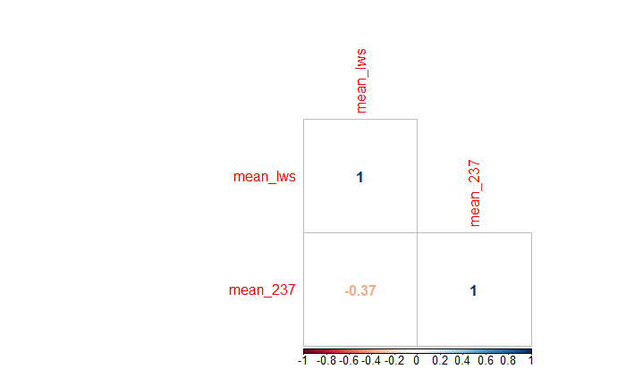

```r
# colnames(M) <- c("237/11", "237/21", "237/32", "LWS/11", "LWS/21", "LWS/32")
# rownames(M) <- c("237 @ 11C", "237 @ 21C", "237 @ 32C", "LWS @ 11C", "LWS @ 21C", "LWS @ 32C")


corplot <- corrplot::corrplot(M, method="number", type="lower")
```

```r
res1 <- cor.test(corr_data$mean_lws, corr_data$mean_237, conf.level = 0.95)
res1
```

```
    Pearson's product-moment correlation

data:  corr_data$mean_lws and corr_data$mean_237
t = -3.0623, df = 59, p-value = 0.003306
alternative hypothesis: true correlation is not equal to 0
95 percent confidence interval:
 -0.5690806 -0.1306983
sample estimates:
       cor
-0.3703305
```

```r
# corrplot::corrplot(M, addCoef.col = "grey")

# corrplot::corrplot(M, add = TRUE, type = "lower", method = "ellipse", order = "AOE",
#          diag = FALSE, tl.pos = "n", cl.pos = "n")
# corrplot::corrplot(M, method = "number")

#
# cor(trial_data_long$mv, trial_data_long$kohms, method = c("pearson"))
# res1 <- corrplot::cor.mtest(corr_data, conf.level = 0.95)
# res1
```

```r
# plot
corr_data <- tibble(pruned_lws_mv$values, pruned_237_kohms$values)
names(corr_data) <- c("ci_lws", "ci_237")

M <- cor(corr_data, method = c("pearson"))
M
```

```
            ci_lws      ci_237
ci_lws  1.00000000 -0.07615839
ci_237 -0.07615839  1.00000000
```

```r
# corrplot::corrplot(M, method="number")
# # corrplot::corrplot(M, add = TRUE, type = "lower", method = "ellipse", order = "AOE",
# #          diag = FALSE, tl.pos = "n", cl.pos = "n")
# # corrplot::corrplot(M, method = "number")
# # corrplot::corrplot(M, addCoef.col = "grey")
# #
# # cor(trial_data_long$mv, trial_data_long$kohms, method = c("pearson"))
# res1 <- corrplot::cor.mtest(corr_data, conf.level = 0.95)
# res1
```

```r
# 4. With current program compilied and loaded on data logger, identify (provide screen snapshot) for how long one can collect the data on CR310 before it gets overwritten?
```